# MY472 MT 2021 - Assignment 5

*Important note:* In this exercise *do not* use your previous database. Instead use the database `uk_election_tweets_small.sqlite` which is supplied in the assignment repo. Answer questions 2.1 - 2.9 using *SQL syntax only* (sending SQL statements through R is fine, no need to change chunk type).

Connect to `uk_election_tweets_small.sqlite`:

```r
db <- dbConnect(SQLite(), '/Users/sam/Documents/GitHub/assignment-05-samuelthelaus/uk_election_tweets_small.sqlite')
```

2.1 How many tweets are in the `tweets` table? How many users in the `users` table?

```r
# Tweets in tweets (22130)
dbGetQuery(db, "SELECT COUNT(*) AS total_tweets FROM tweets")
```

```
##   total_tweets
## 1        22130
```

```r
# Users in users (5572)
dbGetQuery(db, "SELECT COUNT(*) AS total_users FROM users")
```

```
##   total_users
## 1        5572
```

2.2 How many tweets are replies to politicians/parties? How many accounts are from politicians/parties, how many from other users?

```r
# Replies to politicians/parties (1829)
dbGetQuery(db, "SELECT SUM(in_reply_to_screen_name_in) AS replies
                FROM tweets")
```

```
##   replies
## 1    1829
```

```r
# number of accounts (4517 vs 1055)
dbGetQuery(db, "SELECT CASE WHEN screen_name_in == 1 THEN 'Politician/Party' ELSE 'Other' END AS type, COUNT(*) AS num_accounts
                FROM users
                GROUP BY screen_name_in")
```

```
##               type num_accounts
## 1            Other         4517
## 2 Politician/Party         1055
```

2.3 Which screen_name has posted the highest count of tweets?

```r
# DrTeckKhong with 149 tweets
dbGetQuery(db, "SELECT COUNT(*) as total_tweets, users.screen_name
                FROM tweets JOIN users
                ON tweets.user_id_str = users.user_id_str
                GROUP BY users.screen_name
                ORDER BY total_tweets DESC
                LIMIT 1")
```

```
##   total_tweets screen_name
## 1          149 DrTeckKhong
```

2.4 Who has the highest number of followers?

```r
# RufusHound has 1205426 followers
dbGetQuery(db, "SELECT MAX(followers_count) as top_influencer_vibes, screen_name FROM users")
```

```
##   top_influencer_vibes screen_name
## 1              1205426  RufusHound
```

2.5 Among politicians, who has the highest number of followers?

```r
# jeremycorbyn has 968629 followers
dbGetQuery(db, "SELECT MAX(followers_count) as top_influencer_vibes, screen_name
                FROM users
                WHERE screen_name_in = 1")
```

```
##   top_influencer_vibes  screen_name
## 1               968629 jeremycorbyn
```

2.6 Which tweet has the earliest timestamp in the data? Which the latest?

```r
# To ORDER BY twice, make 2 SELECT statements within select statements
dbGetQuery(db, "SELECT 'First', * FROM (
                  SELECT * FROM tweets ORDER BY created_at_dt ASC LIMIT 1
                  )
                UNION
                SELECT 'Last', * FROM (
                  SELECT * FROM tweets ORDER BY created_at_dt DESC LIMIT 1
                  )")
```

```
##   'First'                           doc_id
## 1   First    tw_json_6_201705261745.json.1
## 2    Last tw_json_6_201706080815.json.5638
##                                                                                                              text
## 1 RT @BenRich66: If you work in tech and are backing @libdems then this will interest you https://t.co/tWDj1dWU6R
## 2           @benastontweet Exactly Theresa May believes in big state, just probably not as much as Jeremy Corbyn.
##   retweet_count favorite_count favorited truncated             id_str
## 1             1              0         0         0 868157285226491905
## 2             0              0         0         0 872728644896141312
##   in_reply_to_screen_name
## 1                    <NA>
## 2           benastontweet
##                                                                                 source
## 1   <a href="http://twitter.com/download/iphone" rel="nofollow">Twitter for iPhone</a>
## 2 <a href="http://twitter.com/download/android" rel="nofollow">Twitter for Android</a>
##   retweeted                     created_at in_reply_to_status_id_str
## 1         0 Fri May 26 17:30:01 +0000 2017                      <NA>
## 2         0 Thu Jun 08 08:14:58 +0000 2017        872722485162258432
##   in_reply_to_user_id_str lang listed_count user_id_str
## 1                    <NA>   en          264    20255744
## 2                60071304   en           11  2511131829
##   in_reply_to_screen_name_in created_at_dt
## 1                          0    1495819801
## 2                          0    1496909698
```

2.7 Which were the top ten accounts which received most replies and how many replies did their tweets get?

```r
dbGetQuery(db, "SELECT in_reply_to_screen_name,
                COUNT(in_reply_to_screen_name) AS count
                FROM tweets
                GROUP BY in_reply_to_screen_name
                ORDER BY count DESC
                LIMIT 10")
```

```
##    in_reply_to_screen_name count
## 1            Conservatives   507
## 2             jeremycorbyn   368
## 3              theresa_may   237
## 4             BorisJohnson   173
## 5                 UKLabour    50
## 6              Jeremy_Hunt    36
## 7            HackneyAbbott    36
## 8                   theSNP    27
## 9            MichelleDewbs    24
## 10              DavidLammy    23
```

2.8 How many tweets contained the word brexit? What proportion of tweets by only politicians contained the word brexit, what proportion of tweets by other users?

```r
# Total mentioning Brexit
dbGetQuery(db,
  "SELECT SUM(CASE WHEN text LIKE '%brexit%' THEN 1 ELSE 0 END)
  AS sum_brexit
  FROM tweets")
```

```
##   sum_brexit
## 1       1058
```

```r
# Proportion from politicians and others
dbGetQuery(db,
  "SELECT SUM(CASE WHEN tweets.text LIKE '%brexit%' THEN 1 ELSE 0 END)*100.0/COUNT(*) AS percent_brexit, users.screen_name_in
  FROM tweets JOIN users
  ON tweets.user_id_str = users.user_id_str
  GROUP BY users.screen_name_in")
```

```
##   percent_brexit screen_name_in
## 1       4.873217              0
## 2       4.703341              1
```

2.9 How many tweets have geolocation information (lat or lon value)? It is good to keep in mind how small this number is and that it can bias outcomes of studies as these tweets are not representative of all other tweets.

```r
# There is no lat or lon column in the tweets table
# Thus we first check how many users have lat/lon data
# This comes out to 0, so there is no geolocation data
dbGetQuery(db, "SELECT SUM(CASE WHEN lat IS NOT NULL OR lon IS NOT NULL THEN 1 ELSE 0 END) FROM users")
```

```
##   SUM(CASE WHEN lat IS NOT NULL OR lon IS NOT NULL THEN 1 ELSE 0 END)
## 1                                                                   0
```

**Exercise 3.**

We can analyse Twitter hashtags and account mentions well with quanteda. Read https://quanteda.io/articles/pkgdown/examples/twitter.html and answer the following questions. Obtain the relevant data from the database `uk_election_tweets_small.sqlite` with a SQL query here and answer all questions 3.1 - 3.3 afterwards with `quanteda` rather than SQL.

```r
# Not really necessary as we already connected, but might as well
db <- dbConnect(SQLite(), '/Users/sam/Documents/GitHub/assignment-05-samuelthelaus/uk_election_tweets_small.sqlite')

text_data <- dbGetQuery(db, "SELECT text FROM tweets")
```

3.1 What are the top 10 popular hashtags?

```r
# Get all hashtags, unlist, sort and select top 10
ht <- str_extract_all(text_data$text, "#[A-Za-z0-9_]+")
ht <- unlist(ht)
sort(table(ht), decreasing = TRUE)[1:10]
```

```
## ht
##            #GE2017        #ForTheMany        #VoteLabour #BattleForNumber10
##               1573                725                686                595
##         #BBCDebate              #GE17           #VoteSNP        #VoteLibDem
##                342                325                268                143
##  #VoteConservative            #Brexit
##                141                134
```

3.2 Who was mentioned (i.e. ‘@name’) the most in tweets?

```r
# Mentioned most was Jeremy Corbyn
mentions <- str_extract_all(text_data$text, "@[A-Za-z0-9_]+")
mentions <- unlist(mentions)
sort(table(mentions), decreasing = TRUE)[1]
```

```
## @jeremycorbyn
##          2883
```

3.3 Choose a small number of hashtags or accounts that could be interesting to analyse (e.g. about one topic or a group of politicians). Visualise how these hashtags or user mentions are related in a network with `textplot_network` from `quanteda.textplots`. What do you find?

## Answer

*The plot was made looking at tweets that mention water. The resulting plot seems to have a few clusters. One mentioning tories (tori), TPIMs (Terrorism Prevention and Investigation Measures), Labour, and govt, perhaps related mainly to government topics. Another cluster has key words such as paid, ownership, and dividend, perhaps talking about water investments. Another cluster mentions “energi”, “video” and “explain”, maybe being more focused on work and innovation around water. There are a few tweets that don’t necessarily fall into a cluster, for example the user @jimwaterson, that happens to have water in the name.*

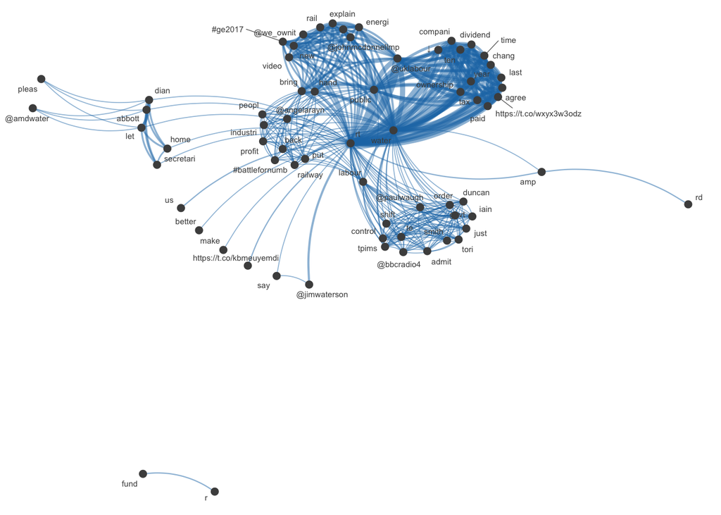

```r
# We select texts that mention water (for no particular reason)
# This gives us 69 tweets
text_data2 <- dbGetQuery(db, "SELECT text FROM tweets
                              WHERE text LIKE '%water%'")

# We process the data and make dfm
dfm <- text_data2$text %>%
  corpus() %>%
  tokens(remove_punct = TRUE, remove_numbers = TRUE) %>%
  tokens_remove(stopwords('en')) %>%
  tokens_wordstem() %>%
  dfm() %>%
  dfm_trim(min_termfreq = 2)

# Plot (reduce vertex label size to see more words)
textplot_network(dfm, vertex_labelsize = 2)
```

```r
# Disconnect from db
dbDisconnect(db)
```

**Exercise 4.**

Revisiting the data sources from Assignment 4, the [World Health Organization](https://www.who.int/data/gho), [St. Louis Federal Reserve](https://fred.stlouisfed.org/), and/or data on wealth and income inequality from the [World Inequality Database](https://wid.world/data/), download some data (no need to use the APIs here) and organise it in a `SQLite` database. Before storing the tables in the database, use R packages such as `dplyr` to reshape and process the data. The final database should contain at least 2 tables. More comprehensive and well thought through databases that link data from different data sources will receive higher marks here. We will grade the knitted HTML file, but feel free to store the database within your submission folder to allow us to check any errors in RStudio (not essential). Do note, however, that if the database is very large any GitHub push/pulls will be slower and less reliable for you when submitting and us when marking.

Download and process data into a final `SQLite` database. Briefly describe why you structured the database the way you did. Then use SQL queries to:

1. Print out the total number of rows for each table in your database. Print out the column names for each table.
2. Print out the first 10 rows for each table.
3. Show whether all tables in the database can be (directly or indirectly) joined with SQL queries. Print out the first 5 rows of the joined tables.

```r
# We import the data and clean each table
# we make an iso3c country_code column to be able to combine them

# Malaria deaths (from WHO)
malaria_deaths <- read.csv('/Users/sam/Desktop/week4/q4/malaria_deaths.csv')

malaria_deaths <- malaria_deaths %>%
  select(ParentLocationCode, ParentLocation,
         SpatialDimValueCode, Location, Period,
         FactValueNumeric)

colnames(malaria_deaths) <- c('parent_loc_code', 'parent_location',
                              'country_code', 'country', 'year',
                              'deaths')

malaria_deaths$country_code <- countrycode(malaria_deaths$country, origin = 'country.name', destination = 'iso3c')

# Hospital beds per 10,000 population (from WHO)
hospital_beds <- read.csv('/Users/sam/Desktop/week4/q4/hospital_beds.csv')

hospital_beds <- hospital_beds %>%
  select(ParentLocationCode, ParentLocation,
         SpatialDimValueCode, Location, Period,
         FactValueNumeric)

colnames(hospital_beds) <- c('parent_loc_code', 'parent_location',
                              'country_code', 'country', 'year',
                              'beds')

hospital_beds$country_code <- countrycode(hospital_beds$country, origin = 'country.name', destination = 'iso3c')

# Median age (from WHO)
median_age <- read.csv('/Users/sam/Desktop/week4/q4/median_age.csv')

median_age <- median_age %>%
  select(ParentLocationCode, ParentLocation,
         SpatialDimValueCode, Location, Period,
         FactValueNumeric)

colnames(median_age) <- c('parent_loc_code', 'parent_location',
                              'country_code', 'country', 'year',
                              'age')

median_age$country_code <- countrycode(median_age$country, origin = 'country.name', destination = 'iso3c')

# US unemployment rate (from FRED)
unrate <- read.csv('/Users/sam/Desktop/week4/q4/UNRATE.csv')

unrate <- unrate %>%
  mutate(year = as.numeric(substr(DATE, 1, 4)))

colnames(unrate) <- c('date', 'unrate', 'year')

unrate$country_code <- countrycode(rep('USA', nrow(unrate)), origin = 'country.name', destination = 'iso3c')

# GDP per adult (from WID)
# here we remove NAs as some rows contain information on whole continents (not countries, which we like to look at)
gdp_per_adult <- read.csv('/Users/sam/Desktop/week4/q4/gdp_per_adult.csv', sep = ';', header = F, skip = 1)

gdp_per_adult <- gdp_per_adult %>%
  select(V1, V4, V5)

colnames(gdp_per_adult) <- c('country', 'year', 'gdp_per_adult')

gdp_per_adult$country_code <- countrycode(gdp_per_adult$country, origin = 'country.name', destination = 'iso3c')
gdp_per_adult <- gdp_per_adult %>%
  drop_na()

# Create database
db <- dbConnect(SQLite(), '/Users/sam/Desktop/week4/mydata-db.sqlite')

# Write tables
dbWriteTable(db, 'malaria_deaths', malaria_deaths, overwrite = T)
dbWriteTable(db, 'hospital_beds', hospital_beds, overwrite = T)
dbWriteTable(db, 'median_age', median_age, overwrite = T)
dbWriteTable(db, 'unrate', unrate, overwrite = T)
dbWriteTable(db, 'gdp_per_adult', gdp_per_adult, overwrite = T)


# Number of rows of each table
dbGetQuery(db, "SELECT COUNT(*) FROM malaria_deaths")
```

```
##   COUNT(*)
## 1      856
```

```r
dbGetQuery(db, "SELECT COUNT(*) FROM hospital_beds")
```

```
##   COUNT(*)
## 1     1770
```

```r
dbGetQuery(db, "SELECT COUNT(*) FROM median_age")
```

```
##   COUNT(*)
## 1      366
```

```r
dbGetQuery(db, "SELECT COUNT(*) FROM unrate")
```

```
##   COUNT(*)
## 1      155
```

```r
dbGetQuery(db, "SELECT COUNT(*) FROM gdp_per_adult")
```

```
##   COUNT(*)
## 1     1890
```

```r
# Column names of each table
dbGetQuery(db, "PRAGMA TABLE_INFO(malaria_deaths)")
```

```
##   cid            name    type notnull dflt_value pk
## 1   0 parent_loc_code    TEXT       0         NA  0
## 2   1 parent_location    TEXT       0         NA  0
## 3   2    country_code    TEXT       0         NA  0
## 4   3         country    TEXT       0         NA  0
## 5   4            year INTEGER       0         NA  0
## 6   5          deaths INTEGER       0         NA  0
```

```r
dbGetQuery(db, "PRAGMA TABLE_INFO(hospital_beds)")
```

```
##   cid            name    type notnull dflt_value pk
## 1   0 parent_loc_code    TEXT       0         NA  0
## 2   1 parent_location    TEXT       0         NA  0
## 3   2    country_code    TEXT       0         NA  0
## 4   3         country    TEXT       0         NA  0
## 5   4            year INTEGER       0         NA  0
## 6   5            beds    REAL       0         NA  0
```

```r
dbGetQuery(db, "PRAGMA TABLE_INFO(median_age)")
```

```
##   cid            name    type notnull dflt_value pk
## 1   0 parent_loc_code    TEXT       0         NA  0
## 2   1 parent_location    TEXT       0         NA  0
## 3   2    country_code    TEXT       0         NA  0
## 4   3         country    TEXT       0         NA  0
## 5   4            year INTEGER       0         NA  0
## 6   5             age    REAL       0         NA  0
```

```r
dbGetQuery(db, "PRAGMA TABLE_INFO(unrate)")
```

```
##   cid         name type notnull dflt_value pk
## 1   0         date TEXT       0         NA  0
## 2   1       unrate REAL       0         NA  0
## 3   2         year REAL       0         NA  0
## 4   3 country_code TEXT       0         NA  0
```

```r
dbGetQuery(db, "PRAGMA TABLE_INFO(gdp_per_adult)")
```

```
##   cid          name    type notnull dflt_value pk
## 1   0       country    TEXT       0         NA  0
## 2   1          year INTEGER       0         NA  0
## 3   2 gdp_per_adult    REAL       0         NA  0
## 4   3  country_code    TEXT       0         NA  0
```

```r
# Print first 10 rows of each table
dbGetQuery(db, "SELECT * FROM malaria_deaths LIMIT 10")
```

```
##    parent_loc_code parent_location country_code
## 1              AFR          Africa          DZA
## 2              AMR        Americas          ARG
## 3              EUR          Europe          ARM
## 4              EUR          Europe          AZE
## 5              AMR        Americas          BLZ
## 6             SEAR South-East Asia          BTN
## 7              WPR Western Pacific          CHN
## 8              AMR        Americas          COL
## 9              AMR        Americas          CRI
## 10            SEAR South-East Asia          PRK
##                                  country year deaths
## 1                                Algeria 2017      0
## 2                              Argentina 2017      0
## 3                                Armenia 2017      0
## 4                             Azerbaijan 2017      0
## 5                                 Belize 2017      0
## 6                                 Bhutan 2017      0
## 7                                  China 2017      0
## 8                               Colombia 2017      0
## 9                             Costa Rica 2017      0
## 10 Democratic People's Republic of Korea 2017      0
```

```r
dbGetQuery(db, "SELECT * FROM hospital_beds LIMIT 10")
```

```
##    parent_loc_code parent_location country_code
## 1              AMR        Americas          CRI
## 2              EUR          Europe          GBR
## 3              AMR        Americas          CAN
## 4              WPR Western Pacific          NZL
## 5              EUR          Europe          DNK
## 6              EUR          Europe          ISL
## 7              EUR          Europe          LUX
## 8              EUR          Europe          BEL
## 9              AMR        Americas          CRI
## 10             WPR Western Pacific          KOR
##                                                 country year  beds
## 1                                            Costa Rica 2019  11.0
## 2  United Kingdom of Great Britain and Northern Ireland 2019  24.6
## 3                                                Canada 2019  25.2
## 4                                           New Zealand 2019  25.7
## 5                                               Denmark 2019  26.0
## 6                                               Iceland 2019  28.3
## 7                                            Luxembourg 2019  42.6
## 8                                               Belgium 2019  55.8
## 9                                            Costa Rica 2018  11.1
## 10                                    Republic of Korea 2018 124.3
```

```r
dbGetQuery(db, "SELECT * FROM median_age LIMIT 10")
```

```
##    parent_loc_code       parent_location country_code     country year  age
## 1              AFR                Africa          NER       Niger 2013 15.0
## 2              AFR                Africa          TCD        Chad 2013 15.8
## 3              AFR                Africa          UGA      Uganda 2013 15.8
## 4              AFR                Africa          AGO      Angola 2013 16.3
## 5              AFR                Africa          MLI        Mali 2013 16.3
## 6              EMR Eastern Mediterranean          SOM     Somalia 2013 16.3
## 7              EMR Eastern Mediterranean          AFG Afghanistan 2013 16.5
## 8             SEAR       South-East Asia          TLS Timor-Leste 2013 16.6
## 9              AFR                Africa          ZMB      Zambia 2013 16.6
## 10             AFR                Africa          GMB      Gambia 2013 17.0
```

```r
dbGetQuery(db, "SELECT * FROM unrate LIMIT 10")
```

```
##          date unrate year country_code
## 1  2009-01-01    7.8 2009          USA
## 2  2009-02-01    8.3 2009          USA
## 3  2009-03-01    8.7 2009          USA
## 4  2009-04-01    9.0 2009          USA
## 5  2009-05-01    9.4 2009          USA
## 6  2009-06-01    9.5 2009          USA
## 7  2009-07-01    9.5 2009          USA
## 8  2009-08-01    9.6 2009          USA
## 9  2009-09-01    9.8 2009          USA
## 10 2009-10-01   10.0 2009          USA
```

```r
dbGetQuery(db, "SELECT * FROM gdp_per_adult LIMIT 10")
```

```
##        country year gdp_per_adult country_code
## 1  Afghanistan 2010      3600.842          AFG
## 2  Afghanistan 2011      3486.015          AFG
## 3  Afghanistan 2012      3768.870          AFG
## 4  Afghanistan 2013      3803.590          AFG
## 5  Afghanistan 2014      3731.341          AFG
## 6  Afghanistan 2015      3618.588          AFG
## 7  Afghanistan 2016      3553.717          AFG
## 8  Afghanistan 2017      3510.270          AFG
## 9  Afghanistan 2018      3422.744          AFG
## 10 Afghanistan 2019      3428.496          AFG
```

```r
# JOIN all tables
# Start with gdp_per_adult as it has most data and left join
dbGetQuery(db, "SELECT * FROM gdp_per_adult
           LEFT JOIN malaria_deaths ON gdp_per_adult.country_code = malaria_deaths.country_code
           LEFT JOIN hospital_beds ON gdp_per_adult.country_code = hospital_beds.country_code
           LEFT JOIN median_age ON gdp_per_adult.country_code = median_age.country_code
           LEFT JOIN unrate ON gdp_per_adult.country_code = unrate.country_code
           LIMIT 5")
```

```
##       country year gdp_per_adult country_code parent_loc_code
## 1 Afghanistan 2010      3600.842          AFG             EMR
## 2 Afghanistan 2010      3600.842          AFG             EMR
## 3 Afghanistan 2010      3600.842          AFG             EMR
## 4 Afghanistan 2010      3600.842          AFG             EMR
## 5 Afghanistan 2010      3600.842          AFG             EMR
##         parent_location country_code     country year deaths parent_loc_code
## 1 Eastern Mediterranean          AFG Afghanistan 2010    200             EMR
## 2 Eastern Mediterranean          AFG Afghanistan 2010    200             EMR
## 3 Eastern Mediterranean          AFG Afghanistan 2010    200             EMR
## 4 Eastern Mediterranean          AFG Afghanistan 2010    200             EMR
## 5 Eastern Mediterranean          AFG Afghanistan 2010    200             EMR
##         parent_location country_code     country year beds parent_loc_code
## 1 Eastern Mediterranean          AFG Afghanistan 2000  3.0             EMR
## 2 Eastern Mediterranean          AFG Afghanistan 2000  3.0             EMR
## 3 Eastern Mediterranean          AFG Afghanistan 2001  3.9             EMR
## 4 Eastern Mediterranean          AFG Afghanistan 2001  3.9             EMR
## 5 Eastern Mediterranean          AFG Afghanistan 2002  3.9             EMR
##         parent_location country_code     country year  age date unrate year
## 1 Eastern Mediterranean          AFG Afghanistan 2012 16.2 <NA>     NA   NA
## 2 Eastern Mediterranean          AFG Afghanistan 2013 16.5 <NA>     NA   NA
## 3 Eastern Mediterranean          AFG Afghanistan 2012 16.2 <NA>     NA   NA
## 4 Eastern Mediterranean          AFG Afghanistan 2013 16.5 <NA>     NA   NA
## 5 Eastern Mediterranean          AFG Afghanistan 2012 16.2 <NA>     NA   NA
##   country_code
## 1         <NA>
## 2         <NA>
## 3         <NA>
## 4         <NA>
## 5         <NA>
```

```r
# Then show that all tables can be individually joined to the other tables

# Start with gdp_per_adult
dbGetQuery(db, "SELECT * FROM gdp_per_adult
           JOIN malaria_deaths ON gdp_per_adult.country_code = malaria_deaths.country_code
           LIMIT 5")
```

```
##       country year gdp_per_adult country_code parent_loc_code
## 1 Afghanistan 2010      3600.842          AFG             EMR
## 2 Afghanistan 2010      3600.842          AFG             EMR
## 3 Afghanistan 2010      3600.842          AFG             EMR
## 4 Afghanistan 2010      3600.842          AFG             EMR
## 5 Afghanistan 2010      3600.842          AFG             EMR
##         parent_location country_code     country year deaths
## 1 Eastern Mediterranean          AFG Afghanistan 2010    200
## 2 Eastern Mediterranean          AFG Afghanistan 2011    242
## 3 Eastern Mediterranean          AFG Afghanistan 2012    117
## 4 Eastern Mediterranean          AFG Afghanistan 2013     99
## 5 Eastern Mediterranean          AFG Afghanistan 2014    136
```

```r
dbGetQuery(db, "SELECT * FROM gdp_per_adult
           JOIN hospital_beds ON gdp_per_adult.country_code = hospital_beds.country_code
           LIMIT 5")
```

```
##       country year gdp_per_adult country_code parent_loc_code
## 1 Afghanistan 2010      3600.842          AFG             EMR
## 2 Afghanistan 2010      3600.842          AFG             EMR
## 3 Afghanistan 2010      3600.842          AFG             EMR
## 4 Afghanistan 2010      3600.842          AFG             EMR
## 5 Afghanistan 2010      3600.842          AFG             EMR
##         parent_location country_code     country year beds
## 1 Eastern Mediterranean          AFG Afghanistan 2000  3.0
## 2 Eastern Mediterranean          AFG Afghanistan 2001  3.9
## 3 Eastern Mediterranean          AFG Afghanistan 2002  3.9
## 4 Eastern Mediterranean          AFG Afghanistan 2003  3.9
## 5 Eastern Mediterranean          AFG Afghanistan 2004  3.9
```

```r
dbGetQuery(db, "SELECT * FROM gdp_per_adult
           JOIN median_age ON gdp_per_adult.country_code = median_age.country_code
           LIMIT 5")
```

```
##       country year gdp_per_adult country_code parent_loc_code
## 1 Afghanistan 2010      3600.842          AFG             EMR
## 2 Afghanistan 2010      3600.842          AFG             EMR
## 3 Afghanistan 2011      3486.015          AFG             EMR
## 4 Afghanistan 2011      3486.015          AFG             EMR
## 5 Afghanistan 2012      3768.870          AFG             EMR
##         parent_location country_code     country year  age
## 1 Eastern Mediterranean          AFG Afghanistan 2012 16.2
## 2 Eastern Mediterranean          AFG Afghanistan 2013 16.5
## 3 Eastern Mediterranean          AFG Afghanistan 2012 16.2
## 4 Eastern Mediterranean          AFG Afghanistan 2013 16.5
## 5 Eastern Mediterranean          AFG Afghanistan 2012 16.2
```

```r
dbGetQuery(db, "SELECT * FROM gdp_per_adult
           JOIN unrate ON gdp_per_adult.country_code = unrate.country_code
           LIMIT 5")
```

```
##   country year gdp_per_adult country_code       date unrate year country_code
## 1     USA 2010      55786.53          USA 2009-01-01    7.8 2009          USA
## 2     USA 2010      55786.53          USA 2009-02-01    8.3 2009          USA
## 3     USA 2010      55786.53          USA 2009-03-01    8.7 2009          USA
## 4     USA 2010      55786.53          USA 2009-04-01    9.0 2009          USA
## 5     USA 2010      55786.53          USA 2009-05-01    9.4 2009          USA
```

```r
# malaria_deaths
dbGetQuery(db, "SELECT * FROM malaria_deaths
           JOIN hospital_beds ON malaria_deaths.country_code = hospital_beds.country_code
           LIMIT 5")
```

```
##   parent_loc_code parent_location country_code   country year deaths
## 1             AFR          Africa          DZA   Algeria 2017      0
## 2             AFR          Africa          DZA   Algeria 2017      0
## 3             AMR        Americas          ARG Argentina 2017      0
## 4             AMR        Americas          ARG Argentina 2017      0
## 5             AMR        Americas          ARG Argentina 2017      0
##   parent_loc_code parent_location country_code   country year  beds
## 1             AFR          Africa          DZA   Algeria 2004 17.00
## 2             AFR          Africa          DZA   Algeria 2015 19.00
## 3             AMR        Americas          ARG Argentina 2011 43.91
## 4             AMR        Americas          ARG Argentina 2012 45.88
## 5             AMR        Americas          ARG Argentina 2013 47.79
```

```r
dbGetQuery(db, "SELECT * FROM malaria_deaths
           JOIN median_age ON malaria_deaths.country_code = median_age.country_code
           LIMIT 5")
```

```
##   parent_loc_code parent_location country_code   country year deaths
## 1             AFR          Africa          DZA   Algeria 2017      0
## 2             AFR          Africa          DZA   Algeria 2017      0
## 3             AMR        Americas          ARG Argentina 2017      0
## 4             AMR        Americas          ARG Argentina 2017      0
## 5             EUR          Europe          ARM   Armenia 2017      0
##   parent_loc_code parent_location country_code   country year   age
## 1             AFR          Africa          DZA   Algeria 2012 26.62
## 2             AFR          Africa          DZA   Algeria 2013 26.90
## 3             AMR        Americas          ARG Argentina 2012 30.83
## 4             AMR        Americas          ARG Argentina 2013 31.10
## 5             EUR          Europe          ARM   Armenia 2012 32.30
```

```r
dbGetQuery(db, "SELECT * FROM malaria_deaths
           JOIN unrate ON malaria_deaths.country_code = unrate.country_code
           LIMIT 5")
```

```
##  [1] parent_loc_code parent_location country_code    country
##  [5] year            deaths          date            unrate
##  [9] year            country_code
## <0 rows> (or 0-length row.names)
```

```r
# hospital_beds
dbGetQuery(db, "SELECT * FROM hospital_beds
           JOIN median_age ON hospital_beds.country_code = median_age.country_code
           LIMIT 5")
```

```
##   parent_loc_code parent_location country_code
## 1             AMR        Americas          CRI
## 2             AMR        Americas          CRI
## 3             EUR          Europe          GBR
## 4             EUR          Europe          GBR
## 5             AMR        Americas          CAN
##                                                country year beds
## 1                                           Costa Rica 2019 11.0
## 2                                           Costa Rica 2019 11.0
## 3 United Kingdom of Great Britain and Northern Ireland 2019 24.6
## 4 United Kingdom of Great Britain and Northern Ireland 2019 24.6
## 5                                               Canada 2019 25.2
##   parent_loc_code parent_location country_code
## 1             AMR        Americas          CRI
## 2             AMR        Americas          CRI
## 3             EUR          Europe          GBR
## 4             EUR          Europe          GBR
## 5             AMR        Americas          CAN
##                                                country year   age
## 1                                           Costa Rica 2012 29.29
## 2                                           Costa Rica 2013 29.70
## 3 United Kingdom of Great Britain and Northern Ireland 2012 40.07
## 4 United Kingdom of Great Britain and Northern Ireland 2013 40.20
## 5                                               Canada 2012 39.99
```

```r
dbGetQuery(db, "SELECT * FROM hospital_beds
           JOIN unrate ON hospital_beds.country_code = unrate.country_code
           LIMIT 5")
```

```
##   parent_loc_code parent_location country_code                  country year
## 1             AMR        Americas          USA United States of America 2017
## 2             AMR        Americas          USA United States of America 2017
## 3             AMR        Americas          USA United States of America 2017
## 4             AMR        Americas          USA United States of America 2017
## 5             AMR        Americas          USA United States of America 2017
##   beds       date unrate year country_code
## 1 28.7 2009-01-01    7.8 2009          USA
## 2 28.7 2009-02-01    8.3 2009          USA
## 3 28.7 2009-03-01    8.7 2009          USA
## 4 28.7 2009-04-01    9.0 2009          USA
## 5 28.7 2009-05-01    9.4 2009          USA
```

```r
# median_age
dbGetQuery(db, "SELECT * FROM median_age
           JOIN unrate ON median_age.country_code = unrate.country_code
           LIMIT 5")
```

```
##   parent_loc_code parent_location country_code                  country year
## 1             AMR        Americas          USA United States of America 2013
## 2             AMR        Americas          USA United States of America 2013
## 3             AMR        Americas          USA United States of America 2013
## 4             AMR        Americas          USA United States of America 2013
## 5             AMR        Americas          USA United States of America 2013
##    age       date unrate year country_code
## 1 37.4 2009-01-01    7.8 2009          USA
## 2 37.4 2009-02-01    8.3 2009          USA
## 3 37.4 2009-03-01    8.7 2009          USA
## 4 37.4 2009-04-01    9.0 2009          USA
## 5 37.4 2009-05-01    9.4 2009          USA
```

```r
# Disconnect from db
dbDisconnect(db)
```